# Reproducible Research: Peer Assessment 1

## Loading libraries

```r
## libraries
library(ggplot2)
library(dplyr)
library(lubridate)
library(knitr)
```

## Loading and preprocessing the data

```r
# Download & unzip file for processing. # Read and load CSV file into a Data Frame.

if (!file.exists('./newData')){dir.create('./newData')}
Url <- "https://d396qusza40orc.cloudfront.net/repdata%2Fdata%2Factivity.zip"
download.file(Url, destfile = "./newData/activity.zip")

# unzip the file
unzip(zipfile = "./newData/activity.zip", exdir = './newData')

# Read csv file
activity <- read.csv("./newData/activity.csv")
```

Process/transform the data (if necessary) into a format suitable for your analysis

```r
# Date conversion
activity$date<-ymd(activity$date)
length(unique(activity$date))
```

```
## [1] 61
```

## What is mean total number of steps taken per day?

Here the missing values in the dataset is ignored

Calculate the total number of steps taken per day

```r
# total number of daily steps
dailySteps <- activity %>%
        group_by(date) %>%
        summarize(sumSteps = sum(steps, na.rm = TRUE))
#Display first 10 rows of data
head(dailySteps,10)
```

```
## # A tibble: 10 x 2
##    date       sumSteps
##    <date>        <int>
##  1 2012-10-01        0
##  2 2012-10-02      126
##  3 2012-10-03    11352
##  4 2012-10-04    12116
##  5 2012-10-05    13294
##  6 2012-10-06    15420
##  7 2012-10-07    11015
##  8 2012-10-08        0
##  9 2012-10-09    12811
## 10 2012-10-10     9900
```

Make a histogram of the total number of steps taken each day

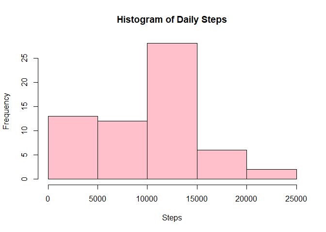

```r
hist(dailySteps$sumSteps, main = "Histogram of Daily Steps", xlab = 'Steps', col = 'pink')
```

Calculate and report the mean and median of the total number of steps taken per day

```r
dailyMeanSteps <- round(mean(dailySteps$sumSteps),digits = 2)
dailyMedianSteps <- round(median(dailySteps$sumSteps),digits = 2)

print(paste("The mean of the total number of daily steps is: ", dailyMeanSteps))
```

```
## [1] "The mean of the total number of daily steps is:  9354.23"
```

```r
print(paste("The median of the total number of daily steps is: ", dailyMedianSteps))
```

```
## [1] "The median of the total number of daily steps is:  10395"
```

## What is the average daily activity pattern?

Make a time series plot (i.e. type = “l”) of the 5-minute interval (x-axis) and the average number of steps taken, averaged across all days (y-axis)

```r
stepsPerInterval <- activity %>%
        group_by(interval) %>%
        summarize(dailyMeanSteps = mean(steps, na.rm = TRUE))
#Display first 10 rows of data
head(stepsPerInterval,10)
```

```
## # A tibble: 10 x 2
##    interval dailyMeanSteps
##       <int>          <dbl>
##  1        0         1.72
##  2        5         0.340
##  3       10         0.132
##  4       15         0.151
##  5       20         0.0755
##  6       25         2.09
##  7       30         0.528
##  8       35         0.868
##  9       40         0
## 10       45         1.47
```

Which 5-minute interval, on average across all the days in the dataset, contains the maximum number of steps?

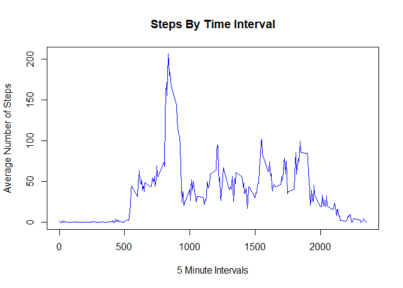

```r
plot(stepsPerInterval$dailyMeanSteps ~ stepsPerInterval$interval,
     col="blue", type="l", xlab = "5 Minute Intervals", ylab = "Average Number of Steps",
     main = "Steps By Time Interval")
```

```r
print(paste("Interval containing the most steps on average: ",stepsPerInterval$interval[which.max(stepsPerInterval$dailyMeanSteps)]))
```

```
## [1] "Interval containing the most steps on average:  835"
```

```r
print(paste("Average steps for that interval: ",round(max(stepsPerInterval$dailyMeanSteps),digits=2)))
```

```
## [1] "Average steps for that interval:  206.17"
```